# Prepare CPUE data from DATRAS exchange

Author

Max Lindmark

Published

2024-12-02

# Intro

In this script, I load exchange data from datras and calculate catch of cod and flounder in unit $\text{kg/km}^2$ (with TVL gear) by size group, by correcting for gear dimensions, sweeplength and trawl speed, following Orio et al 2017.

## Load libraries

```r
# Load libraries, install if needed
pkgs <- c(
  "tidyverse", "tidylog", "RCurl", "devtools", "patchwork",
  "janitor", "icesDatras", "mapdata", "raster", "mapplots"
)

if (length(setdiff(pkgs, rownames(installed.packages()))) > 0) {
  install.packages(setdiff(pkgs, rownames(installed.packages())), dependencies = T)
}

invisible(lapply(pkgs, library, character.only = T))

# Set path
home <- here::here()

theme_set(theme_light())
```

## Read data

```r
# Read HH data
# bits_hh <- getDATRAS(record = "HH", survey = "BITS", years = 2010:2023, quarters = c(1, 4))
# write_csv(bits_hh, paste0(home, "/data/DATRAS/exchange/bits_hh.csv"))
bits_hh <- read_csv(paste0(home, "/data/DATRAS/exchange/bits_hh.csv"))

# Read HL data
# bits_hl <- getDATRAS(record = "HL", survey = "BITS", years = 2010:2023, quarters = c(1, 4))
# write_csv(bits_hl, paste0(home, "/data/DATRAS/exchange/bits_hl.csv"))
bits_hl <- read_csv(paste0(home, "/data/DATRAS/exchange/bits_hl.csv")) |>
  mutate(StNo = as.character(StNo))
# Read CA data
# bits_ca <- getDATRAS(record = "CA", survey = "BITS", years = 2010:2023, quarters = c(1, 4))
# write_csv(bits_ca, paste0(home, "/data/DATRAS/exchange/bits_ca.csv"))
bits_ca <- read_csv(paste0(home, "/data/DATRAS/exchange/bits_ca.csv"))
# Read gear standardization data
newsweep <- read.csv(paste0(home, "/data/trawl-data-historical/Datras/sweep_9116.csv"), sep = ";", fileEncoding = "windows-1252")
```

## Standardize catch data

#### Create a simple haul ID that works across all exchange data

```r
# Create ID column
bits_ca <- bits_ca |>
  mutate(haul_id = paste(Year, Quarter, Country, Ship, Gear, StNo, HaulNo, sep = ":"))

bits_hl <- bits_hl |>
  mutate(haul_id = paste(Year, Quarter, Country, Ship, Gear, StNo, HaulNo, sep = ":"))

bits_hh <- bits_hh |>
  mutate(haul_id = paste(Year, Quarter, Country, Ship, Gear, StNo, HaulNo, sep = ":"))
```

#### Clean DATRAS EXCHANGE data

```r
# Add ICES rectangle
bits_hh$ices_rect <- mapplots::ices.rect2(lon = bits_hh$ShootLong, lat = bits_hh$ShootLat)

# Add ICES subdivisions
shape <- shapefile(paste0(here::here(), "/data/ICES_StatRec_mapto_ICES_Areas/StatRec_map_Areas_Full_20170124.shp"))

pts <- SpatialPoints(cbind(bits_hh$ShootLong, bits_hh$ShootLat),
  proj4string = CRS(proj4string(shape))
)

bits_hh$sub_div <- over(pts, shape)$Area_27

# Rename subdivisions to the more common names and do some more filtering (by sub div and area)
sort(unique(bits_hh$sub_div))
```

```
 [1] "3.a.20"   "3.a.21"   "3.b.23"   "3.c.22"   "3.d.24"   "3.d.25"
 [7] "3.d.26"   "3.d.27"   "3.d.28.2" "3.d.29"
```

```r
bits_hh <- bits_hh |>
  mutate(
    sub_div = factor(sub_div),
    sub_div = fct_recode(sub_div,
      "20" = "3.a.20",
      "21" = "3.a.21",
      "22" = "3.c.22",
      "23" = "3.b.23",
      "24" = "3.d.24",
      "25" = "3.d.25",
      "26" = "3.d.26",
      "27" = "3.d.27",
      "28" = "3.d.28.1",
      "28" = "3.d.28.2",
      "29" = "3.d.29"
    ),
    sub_div = as.character(sub_div)
  )
```

```r
# Select just valid, additional and no oxygen hauls
bits_hh <- bits_hh |>
  filter(HaulVal %in% c("A", "N", "V"))

# Now add the fishing line information from the sweep file (we need that later to standardize based on gear geometry). We add in the the HH data and then transfer it to the other exchange data files when left_joining. Check which Fishing lines I have in the sweep data:
fishing_line <- newsweep |>
  group_by(Gear) |>
  distinct(Fishing.line)

bits_hh <- left_join(bits_hh, fishing_line, by = "Gear")

# Select the hauls in the HH data when subsetting the HL data
bits_hl <- bits_hl |>
  filter(haul_id %in% bits_hh$haul_id)

bits_hh_merge <- bits_hh |>
  mutate(date = paste(Year, Month, Day, sep = "-")) |>
  dplyr::select(
    sub_div, ices_rect, HaulVal, StdSpecRecCode, BySpecRecCode, Fishing.line, Month,
    DataType, HaulDur, GroundSpeed, haul_id, ShootLat, ShootLong, Day, Month, date
  )

bits_hl <- left_join(bits_hl, bits_hh_merge, by = c("haul_id"))
bits_ca <- left_join(bits_ca, bits_hh_merge, by = c("haul_id"))
```

Add in species names (see get_taxa.R)

```r
tax <- read_csv(paste0(home, "/output/taxa.csv"))

bits_hl <- bits_hl |>
  left_join(tax, by = c("SpecCodeType", "SpecCode")) |>
  rename(Species = latin_name)

bits_ca <- bits_ca |>
  left_join(tax, by = c("SpecCodeType", "SpecCode")) |>
  rename(Species = latin_name)

hlcod <- bits_hl |> filter(common_name == "cod")
hlfle <- bits_hl |> filter(common_name == "flounder")
```

#### Prepare to add 0 catches

```r
# Find common columns in the HH and HL data (here already subset by species)
comcol <- intersect(names(hlcod), names(bits_hh))

# Cod: Add 0s and then remove lines with SpecVal = 0 (first NA because we don't have a match in the HH, then make them 0 later)
hlcod0 <- full_join(hlcod, bits_hh[, comcol], by = comcol)

hlcod0$SpecVal[is.na(hlcod0$SpecVal)] <- "zeroCatch"

hlcod0$SpecVal <- factor(hlcod0$SpecVal)

hlcod0 <- hlcod0 |> filter(!SpecVal == "0")

# Add species again after merge
hlcod0$Species <- "Gadus morhua"



# Flounder: Add 0s, remove them if StdSpecRecCode !=1 and then remove lines with SpecVal = 0
hlfle0 <- full_join(hlfle, bits_hh[, comcol], by = comcol)

hlfle0 <- hlfle0[!(is.na(hlfle0$Species) & hlfle0$StdSpecRecCode != 1), ]

hlfle0$SpecVal[is.na(hlfle0$SpecVal)] <- "zeroCatch"
hlfle0$SpecVal <- factor(hlfle0$SpecVal)

hlfle0 <- hlfle0 |> filter(!SpecVal == "0")

hlfle0$Species <- "Platichthys flesus"
```

#### Create (unstandardized) CPUE for `SpecVal=1`. If `DataType=C` then `CPUEun=HLNoAtLngt`, if `DataType=R` then `CPUEun=HLNoAtLngt/(HaulDur/60)`, if `DataType=S` then `CPUEun=(HLNoAtLngt*SubFactor)/(HaulDur/60)`. If `SpecVal="zeroCatch"` then `CPUEun=0`, if `SpecVal=4` we need to decide (no length measurements, only total catch). Note that here we also add zero CPUE if `SpecVal=="zeroCatch"`.

Then I will sum for the same haul the CPUE of the same length classes if they were sampled with different subfactors or with different sexes.

```r
# Cod
hlcod0 <- hlcod0 |>
  mutate(CPUEun = ifelse(SpecVal == "1" & DataType == "C", HLNoAtLngt,
    ifelse(SpecVal == "1" & DataType == "R", HLNoAtLngt / (HaulDur / 60),
      ifelse(SpecVal == "1" & DataType == "S", (HLNoAtLngt * SubFactor) / (HaulDur / 60),
        ifelse(SpecVal == "zeroCatch", 0, NA)
      )
    )
  ))

# Some rows have multiple rows per combination of length class and haul id (i suppose often because it's split by sex), so we need to sum it up
hlcod0 |>
  group_by(LngtClass, haul_id) |>
  mutate(n = n()) |>
  ungroup() |>
  distinct(n)
```

```
# A tibble: 2 × 1
      n
  <int>
1     1
2     2
```

```r
hlcod0 |>
  group_by(LngtClass, haul_id) |>
  mutate(n = n()) |>
  ungroup() |>
  filter(n == 2) |>
  as.data.frame() |>
  head(5)
```

```
  RecordType Survey Quarter Country Ship Gear SweepLngt GearEx DoorType StNo
1         HL   BITS       4      DK 26HI  TVS        NA      S       NA  657
2         HL   BITS       4      DK 26HI  TVS        NA      S       NA  657
3         HL   BITS       4      DK 26HI  TVS        NA      S       NA  657
4         HL   BITS       4      DK 26HI  TVS        NA      S       NA  657
5         HL   BITS       4      DK 26HI  TVS        NA      S       NA  657
  HaulNo Year SpecCodeType SpecCode SpecVal  Sex TotalNo CatIdentifier NoMeas
1     40 2013            W   126436       1 <NA>     256             1     64
2     40 2013            W   126436       1 <NA>     256             1     64
3     40 2013            W   126436       1 <NA>     256             1     64
4     40 2013            W   126436       1 <NA>     256             1     64
5     40 2013            W   126436       1 <NA>      27             2     27
  SubFactor SubWgt CatCatchWgt LngtCode LngtClass HLNoAtLngt DevStage
1         4   1600        6400        .       150          7       NA
2         4   1600        6400        .       160          5       NA
```

[output cut: 27 more lines]

```r
hlcodL <- hlcod0 |>
  group_by(LngtClass, haul_id) |>
  mutate(CPUEun = sum(CPUEun)) |>
  ungroup() |>
  mutate(id3 = paste(haul_id, LngtClass)) |>
  distinct(id3, .keep_all = TRUE) |>
  dplyr::select(-id3) # Clean up a bit

# Check proportion 0 hauls over time
hlcod0 |>
  summarise(CPUEun = sum(CPUEun), .by = c(Year, haul_id)) |>
  mutate(zc = ifelse(CPUEun > 0, "0", "1")) |>
  summarise(prop_z = n(), .by = c(Year, zc)) |>
  pivot_wider(values_from = "prop_z", names_from = "zc") |>
  mutate(prop = (`0` / (`0` + `1`)) * 100)
```

```
# A tibble: 14 × 4
    Year   `0`   `1`  prop
   <dbl> <int> <int> <dbl>
 1  2010   485    72  87.1
 2  2011   483   102  82.6
 3  2012   455    93  83.0
 4  2013   486    69  87.6
 5  2014   445    78  85.1
 6  2015   456    76  85.7
 7  2016   494    97  83.6
 8  2017   558    71  88.7
 9  2018   508   115  81.5
10  2019   501   102  83.1
11  2020   505   114  81.6
12  2021   532   139  79.3
13  2022   526   129  80.3
14  2023   563    70  88.9
```

```r
# Flounder
hlfle0 <- hlfle0 |>
  mutate(CPUEun = ifelse(SpecVal == "1" & DataType == "C", HLNoAtLngt,
    ifelse(SpecVal == "1" & DataType == "R", HLNoAtLngt / (HaulDur / 60),
      ifelse(SpecVal == "1" & DataType == "S", (HLNoAtLngt * SubFactor) / (HaulDur / 60),
        ifelse(SpecVal == "zeroCatch", 0, NA)
      )
    )
  ))

# Some rows have multiple rows per combination of length class and haul id (i suppose often because it's split by sex), so we need to sum it up
hlfle0 |>
  group_by(LngtClass, haul_id) |>
  mutate(n = n()) |>
  ungroup() |>
  distinct(n)
```

```
# A tibble: 2 × 1
      n
  <int>
1     1
2     2
```

```r
hlfle0 |>
  group_by(LngtClass, haul_id) |>
  mutate(n = n()) |>
  ungroup() |>
  filter(n == 2) |>
  as.data.frame() |>
  head(5)
```

```
  RecordType Survey Quarter Country Ship Gear SweepLngt GearEx DoorType  StNo
1         HL   BITS       1      LT LTDA  TVS        NA   <NA>       NA 26134
2         HL   BITS       1      LT LTDA  TVS        NA   <NA>       NA 26134
3         HL   BITS       1      LT LTDA  TVS        NA   <NA>       NA 26134
4         HL   BITS       1      LT LTDA  TVS        NA   <NA>       NA 26134
5         HL   BITS       1      LT LTDA  TVS        NA   <NA>       NA 26134
  HaulNo Year SpecCodeType SpecCode SpecVal Sex TotalNo CatIdentifier NoMeas
1      1 2010            T   172894       1   M      66             1     33
2      1 2010            T   172894       1   M      66             1     33
3      1 2010            T   172894       1   M      66             1     33
4      1 2010            T   172894       1   M      66             1     33
5      1 2010            T   172894       1   M      66             1     33
  SubFactor SubWgt CatCatchWgt LngtCode LngtClass HLNoAtLngt DevStage
1         2  12600       25200        1        22          4       NA
2         2  12600       25200        1        23          8       NA
```

[output cut: 27 more lines]

```r
hlfleL <- hlfle0 |>
  group_by(LngtClass, haul_id) |>
  mutate(CPUEun = sum(CPUEun)) |>
  ungroup() |>
  mutate(id3 = paste(haul_id, LngtClass)) |>
  distinct(id3, .keep_all = TRUE) |>
  dplyr::select(-id3)
```

#### Get and add annual weight-length relationships from the CA data so that I can calculate CPUE in biomass rather than numbers further down

```r
# NOTE! For some species there may not be enough data to have annual LW parameters (!!!)

# Cod
bits_ca_cod <- bits_ca |>
  filter(Species == "Gadus morhua") |>
  mutate(StNo = as.numeric(StNo)) |>
  mutate(ID = paste(Year, Quarter, Country, Ship, Gear, StNo, HaulNo, sep = "."))

# Now I need to copy rows with NoAtLngt > 1 so that 1 row = 1 ind
bits_ca_cod <- bits_ca_cod %>% map_df(., rep, .$CANoAtLngt)

# Standardize length and drop NA weights (need that for condition)
bits_ca_cod <- bits_ca_cod |>
  drop_na(IndWgt) |>
  drop_na(LngtClass) |>
  filter(IndWgt > 0 & LngtClass > 0) |> # Filter positive length and weight
  mutate(weight_kg = IndWgt / 1000) |>
  mutate(length_cm = ifelse(LngtCode == ".",
    LngtClass / 10,
    LngtClass
  )) # Standardize length ((https://vocab.ices.dk/?ref=18))

# Plot
# ggplot(bits_ca_cod, aes(IndWgt, length_cm)) +
#   geom_point() +
#   facet_wrap(~Year)

# Now extract the coefficients for each year (not bothering with outliers at the moment)
lwCOD <- bits_ca_cod %>%
  split(.$Year) |>
  purrr::map(~ lm(log(IndWgt) ~ log(length_cm), data = .x)) |>
  purrr::map_df(broom::tidy, .id = "Year") |>
  dplyr::select(Year, term, estimate) |>
  pivot_wider(names_from = term, values_from = estimate) |>
  mutate(aL = exp(`(Intercept)`)) |>
  dplyr::select(-`(Intercept)`) |>
  rename(b = `log(length_cm)`) |>
  filter(b > 2 & b < 4) |>
  filter(aL > 0.00001 & aL < 0.1) |>
  mutate(Year = as.numeric(Year))

# Flounder
bits_ca_fle <- bits_ca |>
  filter(Species == "Platichthys flesus") |>
  mutate(StNo = as.numeric(StNo)) |>
  mutate(ID = paste(Year, Quarter, Country, Ship, Gear, StNo, HaulNo, sep = "."))

bits_ca_fle <- bits_ca_fle %>% map_df(., rep, .$CANoAtLngt)

# Standardize length and drop NA weights (need that for condition)
bits_ca_fle <- bits_ca_fle |>
  drop_na(IndWgt) |>
  drop_na(LngtClass) |>
  filter(IndWgt > 0 & LngtClass > 0) |> # Filter positive length and weight
  mutate(weight_kg = IndWgt / 1000) |>
  mutate(length_cm = ifelse(LngtCode == ".",
    LngtClass / 10,
    LngtClass
  )) |> # Standardize length ((https://vocab.ices.dk/?ref=18))
  mutate(keep = ifelse(LngtCode == "." & Year == 2008, "N", "Y")) |>
  filter(keep == "Y") |>
  filter(length_cm < 70)

# Plot
# ggplot(bits_ca_fle, aes(IndWgt, length_cm, color = LngtCode)) +
#   geom_point() +
#   facet_wrap(~Year)

# Now extract the coefficients for each year (not bothering with outliers at the moment)
lwFLE <- bits_ca_fle %>%
  split(.$Year) |>
  purrr::map(~ lm(log(IndWgt) ~ log(length_cm), data = .x)) |>
  purrr::map_df(broom::tidy, .id = "Year") |>
  dplyr::select(Year, term, estimate) |>
  pivot_wider(names_from = term, values_from = estimate) |>
  mutate(aL = exp(`(Intercept)`)) |>
  dplyr::select(-`(Intercept)`) |>
  rename(b = `log(length_cm)`) |>
  filter(b > 2 & b < 4) |>
  filter(aL > 0.00001 & aL < 0.1) |>
  mutate(Year = as.numeric(Year))

# Join the annual L-W relationships to the respective catch data to calculate CPUE in biomass not abundance
hlcodL <- left_join(hlcodL, lwCOD, by = "Year")
hlfleL <- left_join(hlfleL, lwFLE, by = "Year")
```

#### Convert from CPUE in numbers to $\text{kg/km}^2$

```r
# Cod
# Standardize length to cm
hlcodL <- hlcodL |>
  mutate(length_cm = ifelse(LngtCode == ".",
    LngtClass / 10,
    LngtClass
  )) # Standardize length ((https://vocab.ices.dk/?ref=18))

# Now check if all rows where length is NA are the ones with zero catch!
hlcodL |>
  filter(CPUEun == 0) |>
  distinct(length_cm)
```

```
# A tibble: 1 × 1
  length_cm
      <dbl>
1        NA
```

```r
hlcodL |>
  filter(is.na(length_cm)) |>
  distinct(CPUEun)
```

```
# A tibble: 1 × 1
  CPUEun
   <dbl>
1      0
```

```r
# In other words, a zero catch is when the catch is zero and length_cm is NA
# In order to not get any NA CPUEs in unit biomass because length is NA (I want them instead to be 0, as the numbers-CPUE is), I will replace length_cm == NA with length_cm == 0 before calculating biomass CPUE
hlcodL <- hlcodL |> mutate(length_cm2 = replace_na(length_cm, 0))

# Calculate weight of catch
hlcodL <- hlcodL |>
  mutate(weight_kg = (aL * length_cm2^b) / 1000) |>
  mutate(CPUEun_kg = weight_kg * CPUEun)

# Plot and check it's correct also in this data
# ggplot(hlcodL, aes(length_cm2, weight_kg)) +
#   geom_point() +
#   facet_wrap(~Year)


# Flounder
# First standardize length to cm and then check how zero-catches are implemented at this stage
hlfleL <- hlfleL |>
  mutate(length_cm = ifelse(LngtCode %in% c(".", "0"),
    LngtClass / 10,
    LngtClass
  )) # Standardize length (https://vocab.ices.dk/?ref=18)

# Now check if all rows where length is NA are the ones with zero catch!
# hlfleL |>
#   mutate(
#     length2 = replace_na(length_cm, -9),
#     no_length = ifelse(length2 < 0, "T", "F")
#     ) |>
#   ggplot(aes(length2, CPUEun, color = no_length)) +
#   geom_point(alpha = 0.2) +
#   facet_wrap(~no_length)

# hlfleL |>
#   mutate(length2 = replace_na(length_cm, -9)) |>
#   group_by(length2) |>
#   distinct(CPUEun) |>
#   arrange(CPUEun)

hlfleL <- hlfleL |> mutate(length_cm2 = replace_na(length_cm, 0))

# Standardize length in the haul-data and calculate weight
hlfleL <- hlfleL |>
  mutate(weight_kg = (aL * length_cm2^b) / 1000) |>
  mutate(CPUEun_kg = weight_kg * CPUEun)

# Plot and check it's correct also in this data
# ggplot(hlfleL, aes(weight_kg, length_cm2)) +
#   geom_point() +
#   facet_wrap(~Year)

# Filter unrealistic size
hlfleL <- hlfleL |> filter(length_cm2 < 400)

# Check
# t <- hlfleL |> drop_na(CPUEun_kg) # Should not have any NA in biomass-catch
# t <- hlfleL |> filter(CPUEun_kg == 0) # Should result in a few percent of rows (note this is not proportion of hauls, but rows)
# t <- hlfleL |> drop_na(length_cm2) # Should be no NA
```

#### Standardize according to Orio

To get unit: kg of fish caught by trawling for 1 h a standard bottom swept area of 0.45km2 using a TVL trawl with 75 m sweeps at the standard speed of three knots

```r
# I will calculate a RS and RSA column in the catch data based on Ale's equation in the sweep file:
# sort(unique(hlcodL2$GroundSpeed))
# sort(unique(hlcodL2$Fishing.line))
# sort(unique(hlcodL2$SweepLngt))

# Here I replace all -9 with NA, and then replace those with the mean values...

# First replace -9 in the columns I use for the calculations with NA so I don't end up with real numbers that are wrong!
hlcodL <- hlcodL |>
  mutate(
    GroundSpeed = ifelse(GroundSpeed == -9, NA, GroundSpeed),
    GroundSpeed = ifelse(is.na(GroundSpeed), median(GroundSpeed, na.rm = TRUE), GroundSpeed),
    SweepLngt = ifelse(SweepLngt == -9, NA, SweepLngt),
    SweepLngt = ifelse(is.na(SweepLngt), median(SweepLngt, na.rm = TRUE), SweepLngt)
  )

hlfleL <- hlfleL |>
  mutate(
    GroundSpeed = ifelse(GroundSpeed == -9, NA, GroundSpeed),
    GroundSpeed = ifelse(is.na(GroundSpeed), median(GroundSpeed, na.rm = TRUE), GroundSpeed),
    SweepLngt = ifelse(SweepLngt == -9, NA, SweepLngt),
    SweepLngt = ifelse(is.na(SweepLngt), median(SweepLngt, na.rm = TRUE), GroundSpeed)
  )

# Now calculate correction factors
hlcodL <- hlcodL |>
  mutate(
    RS_x = 3 / GroundSpeed,
    Horizontal.opening..m. = Fishing.line * 0.67,
    Swep.one.side..after.formula...meter = 0.258819045 * SweepLngt, # SIN(RADIANS(15))
    Size.final..m = Horizontal.opening..m. + (Swep.one.side..after.formula...meter * 2),
    Swept.area = (Size.final..m * 3 * 1860) / 1000000,
    RSA_x = 0.45388309675081 / Swept.area
  ) |>
  filter(RS_x >= 0.59 & RS_x <= 1.93)


hlfleL <- hlfleL |>
  mutate(
    RS_x = 3 / GroundSpeed,
    Horizontal.opening..m. = Fishing.line * 0.67,
    Swep.one.side..after.formula...meter = 0.258819045 * SweepLngt, # SIN(RADIANS(15))
    Size.final..m = Horizontal.opening..m. + (Swep.one.side..after.formula...meter * 2),
    Swept.area = (Size.final..m * 3 * 1860) / 1000000,
    RSA_x = 0.45388309675081 / Swept.area
  ) |>
  filter(RS_x >= 0.59 & RS_x <= 1.93)

# Standardize!
hlcodL <- hlcodL |>
  mutate(
    CPUEst_kg = CPUEun_kg * RS_x * RSA_x,
    CPUEst = CPUEun * RS_x * RSA_x
  )

hlfleL <- hlfleL |>
  mutate(
    CPUEst_kg = CPUEun_kg * RS_x * RSA_x,
    CPUEst = CPUEun * RS_x * RSA_x
  )


# Cod
hlcodL <- hlcodL |>
  mutate(
    biomass_density = CPUEst_kg / 0.45,
    density = CPUEst / 0.45,
  )

# Flounder
hlfleL <- hlfleL |>
  mutate(
    biomass_density = CPUEst_kg / 0.45,
    density = CPUEst / 0.45,
  )
```

## Save data

```r
# Rename columns and select specific columns from the cod data
# Cod
datcod <- hlcodL |>
  dplyr::select(
    density, biomass_density, Year, Species, ShootLat, ShootLong, Quarter,
    Month, Day, date, haul_id, ices_rect, sub_div, length_cm2,
    # FIXME
    CPUEun # For comparing with Alessandro
  ) |>
  janitor::clean_names() |>
  rename(
    lat = shoot_lat,
    lon = shoot_long,
    length_class = length_cm2
  ) |>
  mutate(
    source = "DATRAS",
    length_class = ifelse(length_class == 0, NA, length_class)
  )

# Flounder
datfle <- hlfleL |>
  dplyr::select(
    density, biomass_density, Year, Species, ShootLat, ShootLong, Quarter,
    Month, Day, date, haul_id, ices_rect, sub_div, length_cm2
  ) |>
  janitor::clean_names() |>
  rename(
    lat = shoot_lat,
    lon = shoot_long,
    length_class = length_cm2
  ) |>
  mutate(
    source = "DATRAS",
    length_class = ifelse(length_class == 0, NA, length_class)
  )

write_csv(datcod, paste0(home, "/output/cod_cpue_length.csv"))
write_csv(datfle, paste0(home, "/output/cod_cpue_length.csv"))
```

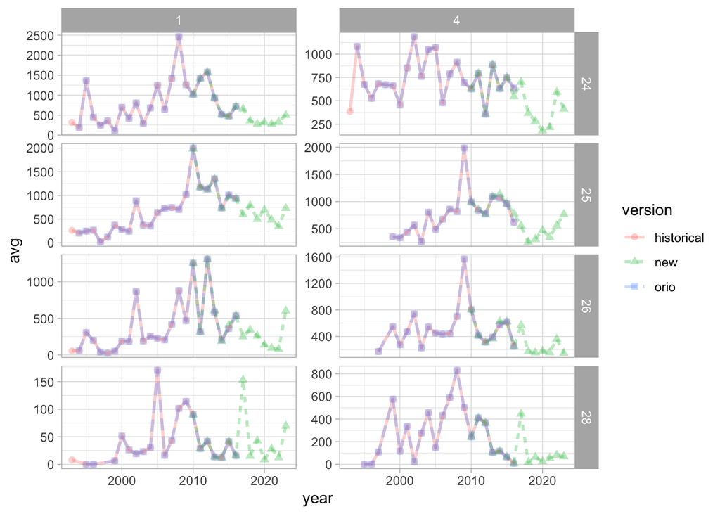

```r
# condition <- readr::read_csv("https://raw.githubusercontent.com/maxlindmark/cod_condition/master/data/for_analysis/catch_q_1_4.csv") |>
#   mutate(sub_div = as.factor(sub_div)) |>
#   filter(year >= 1993) |>
#   filter(sub_div %in% c(24, 25, 26, 27, 28)) |>
#   summarise(mean = median(density), .by = c(sub_div, year, quarter)) |>
#   mutate(version = "condition")

historical <- read_csv(paste0(home, "/output/cod_cpue_length_historical.csv")) |>
  #filter(year >= 1993 & source == "datras" & quarter %in% c(1, 4)) |>
  filter(year >= 1993 & quarter %in% c(1, 4)) |>
  filter(sub_div %in% c(24, 25, 26, 28)) |>
  separate(haul_id, into = c("year2", "q2", "country"), sep = ":", remove = FALSE) |>
  # I can't do the below in Ale's data because the source column isn't there
  mutate(country = ifelse(source == "sweden", "SE", country)) |>
  summarise(sum = sum(CPUEun),
            sum_st = sum(density),
            sumb_st = sum(biomass_density),
            .by = c(haul_id, sub_div, year, quarter, country)) |>
  summarise(avg = mean(sum),
            avg_st = mean(sum_st),
            avgb_st = mean(sumb_st),
            .by = c(sub_div, year, quarter, country)) |>
  mutate(version = "historical")
new <- datcod |>
  filter(sub_div %in% c(24, 25, 26, 28)) |>
  separate(haul_id, into = c("year2", "q2", "country"), sep = ":", remove = FALSE) |>
  summarise(sum = sum(cpu_eun),
            sumb_st = sum(biomass_density),
            sum_st = sum(density),
            .by = c(haul_id, sub_div, year, quarter, country)) |>
  summarise(avg = mean(sum),
            avg_st = mean(sum_st),
            avgb_st = mean(sumb_st),
            .by = c(sub_div, year, quarter, country)) |>
  mutate(version = "new",
         country = ifelse(country == "DK", "DEN", country),
         country = ifelse(country == "PL", "POL", country),
         country = ifelse(country == "RU", "RUS", country),
         country = ifelse(country == "DE", "GFR", country),
         country = ifelse(country == "EE", "EST", country),
         country = ifelse(country == "LT", "LTU", country),
         country = ifelse(country == "LV", "LAT", country))
# This comes from the repo "gear standardization ale"
# Note I have biomass density in grams in that script (forgot to change)
orio <- read.csv("/Users/maxlindmark/Dropbox/Max work/R/gear-standardization-ale/datras_st_ale.csv") |>
  filter(SD %in% c(24, 25, 26, 28)) |>
  mutate(quarter = quarter(date)) |>
  filter(quarter %in% c(1, 4) & year > 1993) |>
  separate(IDX, into = c("year2", "q2", "country"), sep = ":", remove = FALSE) |>
  summarise(sum = sum(CPUEun),
            sumb_st = sum((CPUEstBIOyear/0.45) / 1000),
            sum_st = sum(CPUEst/0.45), .by = c(IDX, SD, year, quarter, country)) |>
  summarise(avg = mean(sum),
            avg_st = mean(sum_st),
            avgb_st = mean(sumb_st),
            .by = c(SD, year, quarter, country)) |>
  mutate(version = "orio") |>
  mutate(sub_div = as.character(SD))
dd <- bind_rows(historical, new, orio)

overlap <- intersect(unique(historical$year),
                     unique(new$year))

# How do the series compare (Sweden remove since it's not in Orio because I filtered source = DATRAS when saving that)
dd |>
  filter(!country == "SE") |>
  summarise(avg = mean(avg), .by = c(sub_div, year, quarter, version)) |>
  ggplot(aes(year, avg, color = version, linetype = version, shape = version)) +
  geom_point(size = 2, alpha = 0.3) +
  geom_line(alpha = 0.3, linewidth = 1) +
  ggh4x::facet_grid2(sub_div ~ quarter, independent = "y", scales = "free")
```

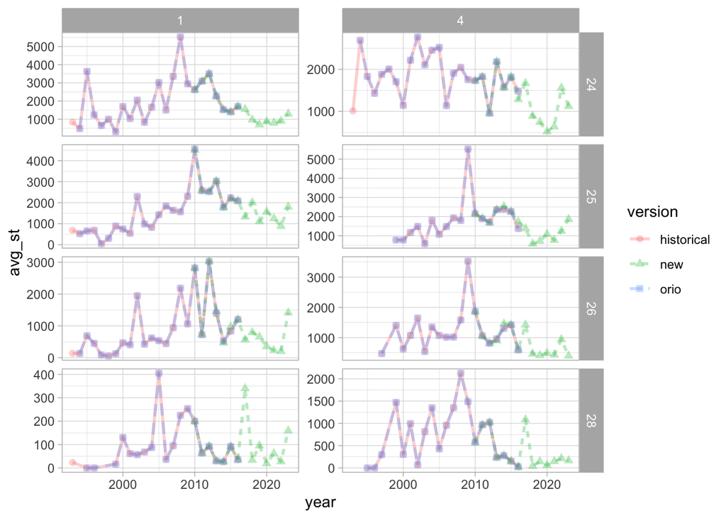

```r
dd |>
  filter(!country == "SE") |>
  summarise(avg_st = mean(avg_st), .by = c(sub_div, year, quarter, version)) |>
  ggplot(aes(year, avg_st, color = version, linetype = version, shape = version)) +
  geom_point(size = 2, alpha = 0.3) +
  geom_line(alpha = 0.3, linewidth = 1) +
  ggh4x::facet_grid2(sub_div ~ quarter, independent = "y", scales = "free")
```

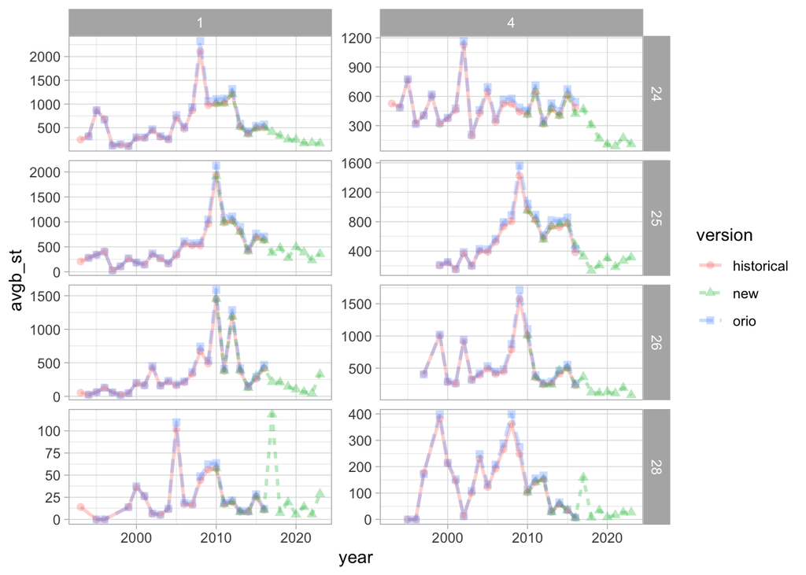

```r
dd |>
  filter(!country == "SE") |>
  summarise(avgb_st = mean(avgb_st), .by = c(sub_div, year, quarter, version)) |>
  ggplot(aes(year, avgb_st, color = version, linetype = version, shape = version)) +
  geom_point(size = 2, alpha = 0.3) +
  geom_line(alpha = 0.3, linewidth = 1) +
  ggh4x::facet_grid2(sub_div ~ quarter, independent = "y", scales = "free")
```

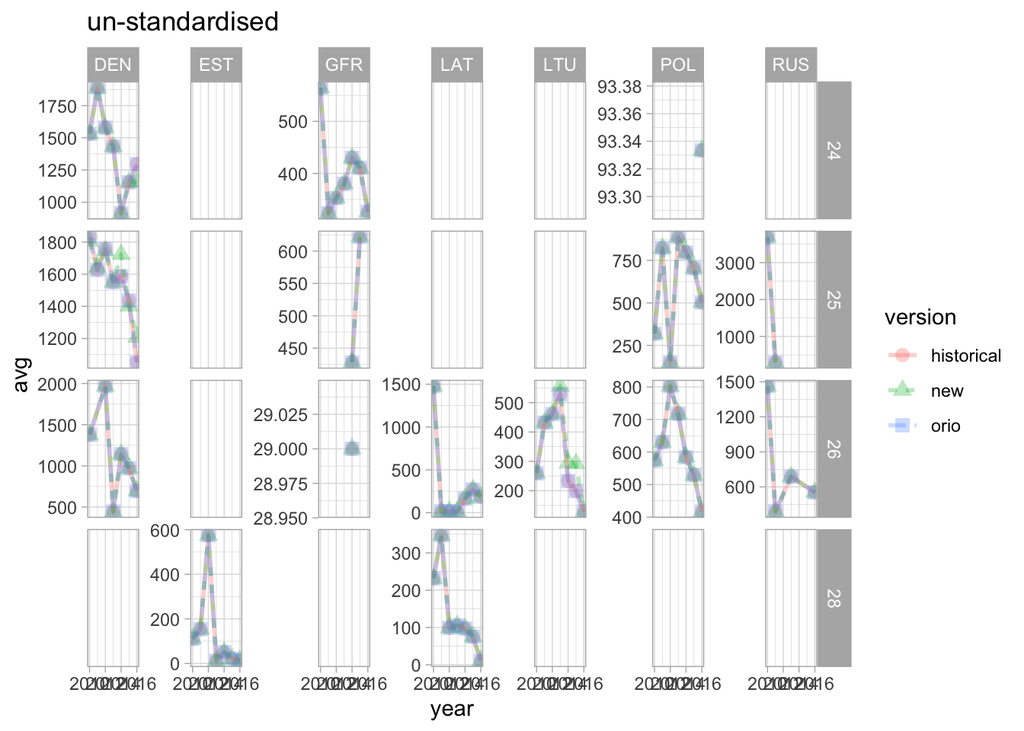

```r
# Compare non swedish data with Orio and the un-standardized density data by country
dd |>
  filter(!country == "SE") |>
  filter(year %in% c(overlap)) |>
  summarise(avg = mean(avg), .by = c(sub_div, year, country, version)) |>
  ggplot(aes(year, avg, color = version, linetype = version, shape = version)) +
  geom_point(size = 3, alpha = 0.3) +
  geom_line(alpha = 0.3, linewidth = 1) +
  ggh4x::facet_grid2(sub_div ~ country, independent = "y", scales = "free") +
  ggtitle("un-standardised")
```

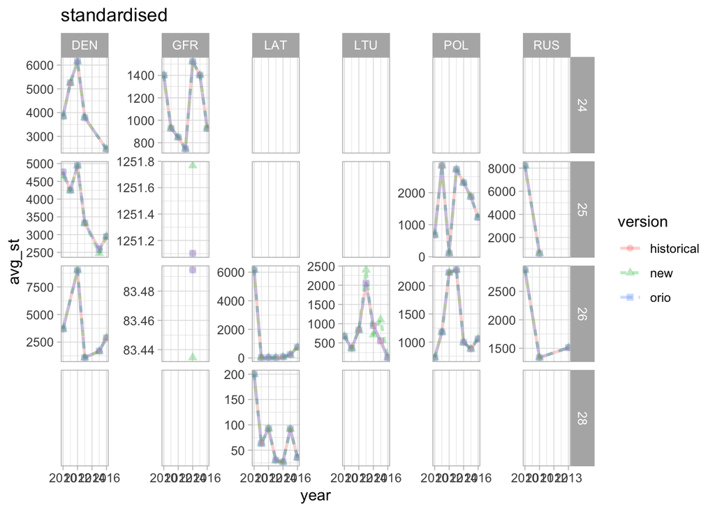

```r
# Compare non swedish data with Orio and the standardized density data by country
dd |>
  filter(!country == "SE" & quarter == 1) |>
  filter(year %in% c(overlap)) |>
  summarise(avg_st = mean(avg_st), .by = c(sub_div, year, country, version)) |>
  ggplot(aes(year, avg_st, color = version, linetype = version, shape = version)) +
  geom_point(size = 2, alpha = 0.3) +
  geom_line(alpha = 0.3, linewidth = 1) +
  ggh4x::facet_grid2(sub_div ~ country, independent = "y", scales = "free") +
  ggtitle("standardised")
```

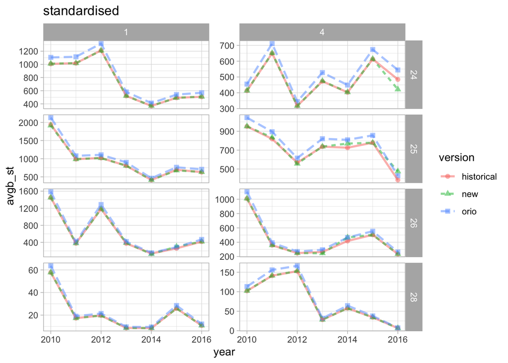

```r
# Compare non swedish data with Orio and the standardized biomass density data
dd |>
  filter(!country == "SE") |>
  filter(year %in% c(overlap)) |>
  summarise(avgb_st = mean(avgb_st), .by = c(sub_div, year, quarter, version)) |>
  ggplot(aes(year, avgb_st, color = version, linetype = version, shape = version)) +
  geom_point(size = 2, alpha = 0.5) +
  geom_line(alpha = 0.5, linewidth = 1) +
  ggh4x::facet_grid2(sub_div ~ quarter, independent = "y", scales = "free") +
  ggtitle("standardised")
```

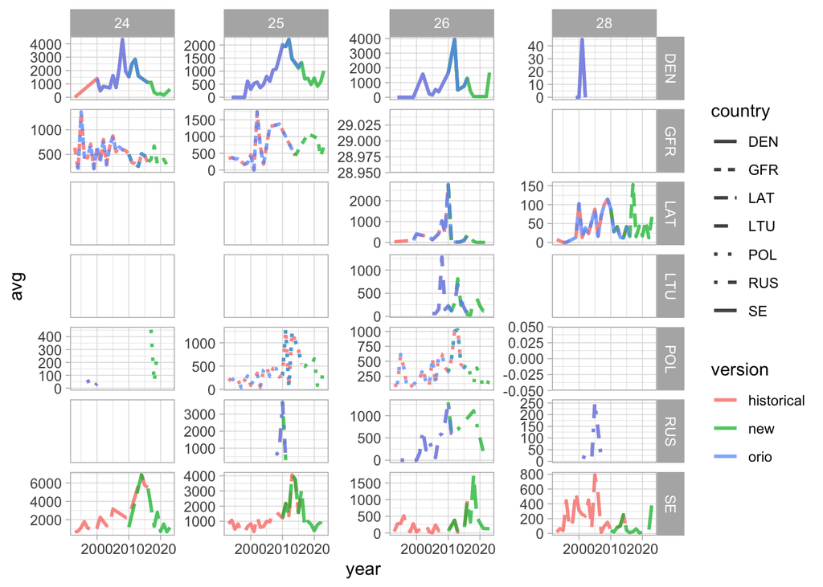

```r
dd |>
  filter(quarter == 1) |>
  ggplot(aes(year, avg, color = version, linetype = country)) +
  geom_line(alpha = 0.75, linewidth = 1) +
  ggh4x::facet_grid2(country ~ sub_div, independent = "y", scales = "free")
```